# Лабораторная работа №2

Дисциплина: Администрирование сетевых подсистем

Бахи сиди али темассини

1032234211@pfur.ru

Российский университет дружбы народов

2026-02-16

# Цель работы

## Цель работы

- Формулировка цели лабораторной работы согласно методическим указаниям
- Упрощение подготовки отчётов с использованием шаблона
- Ознакомление с возможностями разметки Markdown

# Выполнение лабораторной работы

## Установка DNS-сервера

- Выполнен вход под пользователем `bahis`
- Переход в режим суперпользователя `sudo -i`
- Подтверждена смена приглашения на `root`

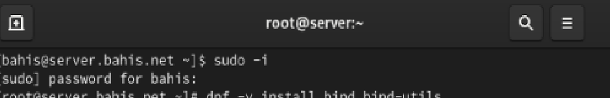

Рисунок 1: Переход в режим суперпользователя sudo -i

- Установлены пакеты `bind` и `bind-utils`
- Использована команда `dnf -y install`
- Транзакция завершена успешно

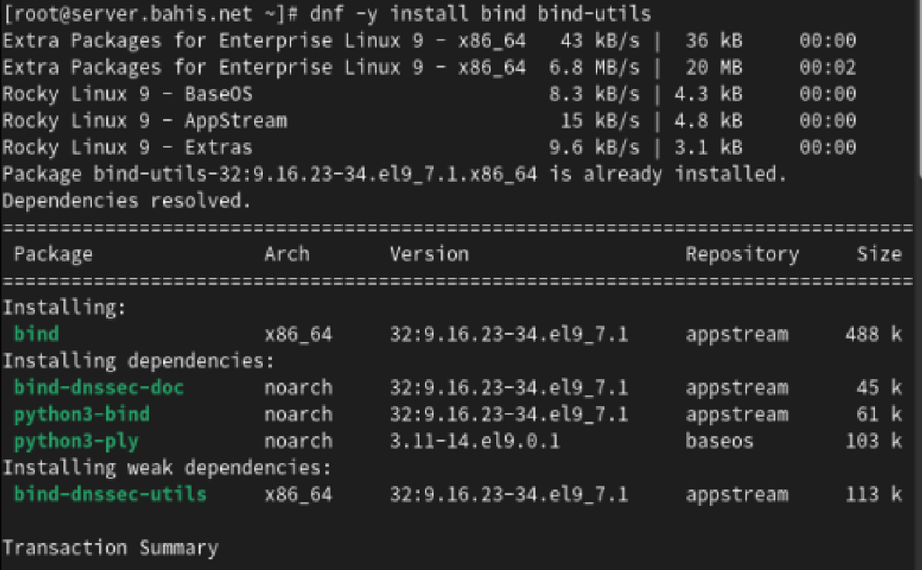

Рисунок 2: Установка пакетов bind и bind-utils через dnf

- Выполнен запрос `dig www.yandex.ru`
- Статус ответа `NOERROR`
- Получены три A-записи
- Подтверждено корректное разрешение имени

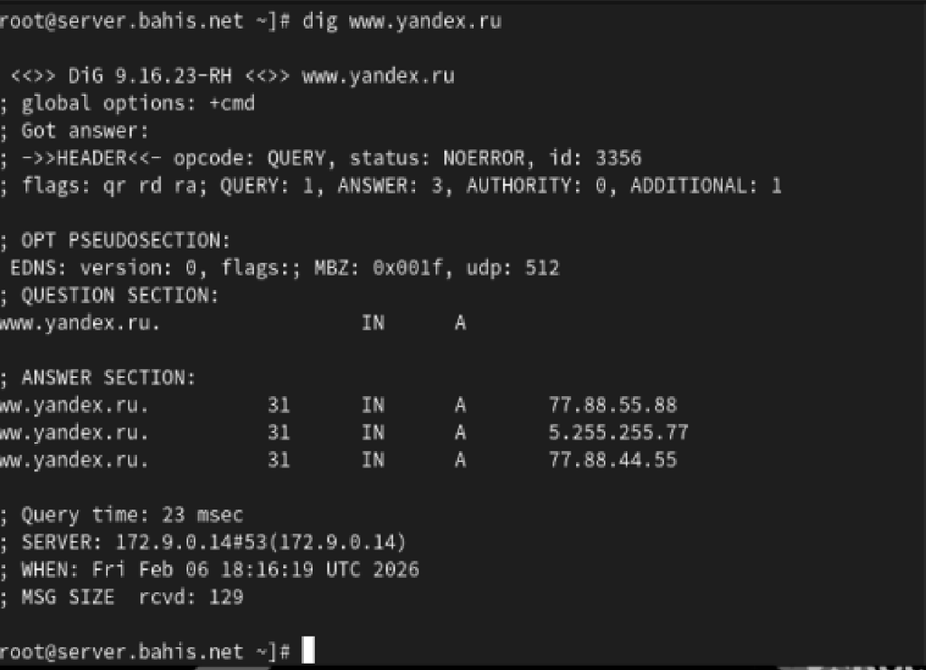

Рисунок 3: Результат запроса dig www.yandex.ru

## Конфигурирование кэширующего DNS-сервера

- Проанализирован `/etc/resolv.conf`
- Указан домен `bahis.net`
- Заданы внешние DNS-серверы

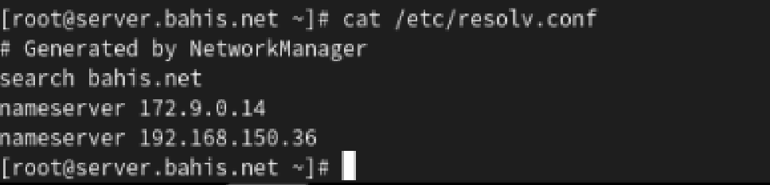

Рисунок 4: Содержимое файла /etc/resolv.conf

- Проанализирован `/etc/named.conf`
- Включена рекурсия `recursion yes`
- Прослушивание на `127.0.0.1`
- Разрешены запросы от localhost

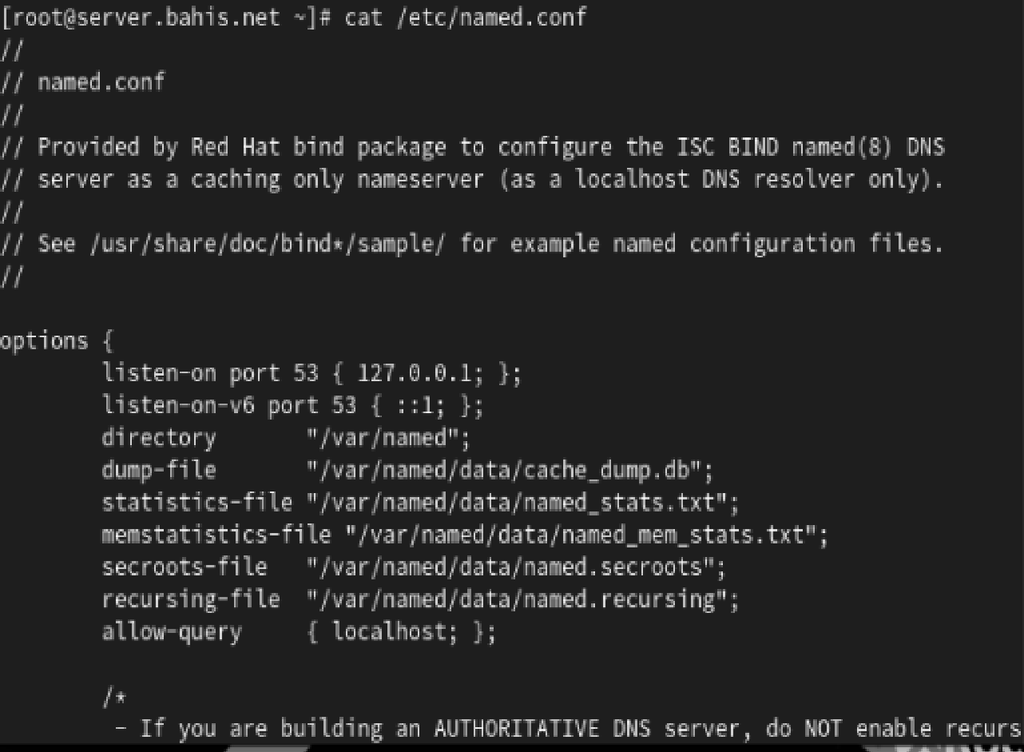

Рисунок 5: Конфигурация файла /etc/named.conf

- Рассмотрен файл `named.ca`
- Содержит корневые NS, A, AAAA-записи

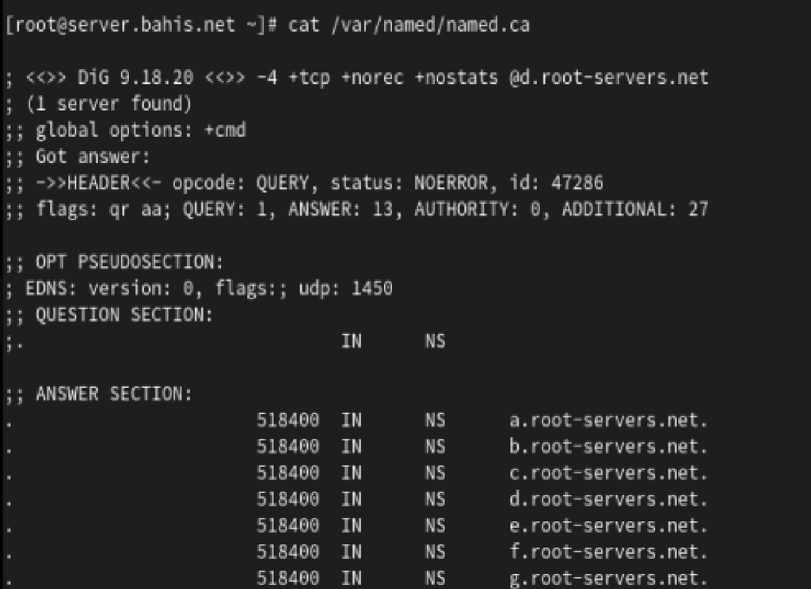

Рисунок 6: Содержимое файла named.ca (корневые серверы)

- Рассмотрен файл `named.localhost`
- Определена зона localhost

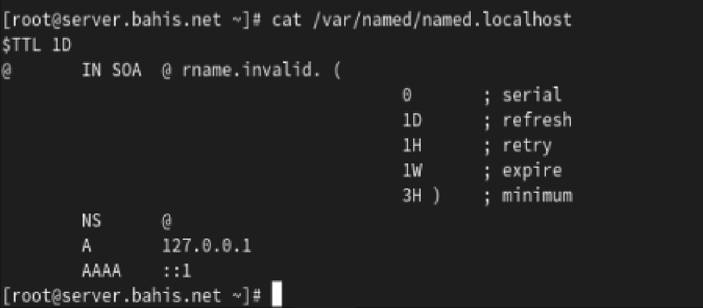

Рисунок 7: Содержимое файла named.localhost

- Рассмотрен файл `named.loopback`
- Настроено обратное разрешение 127.0.0.1

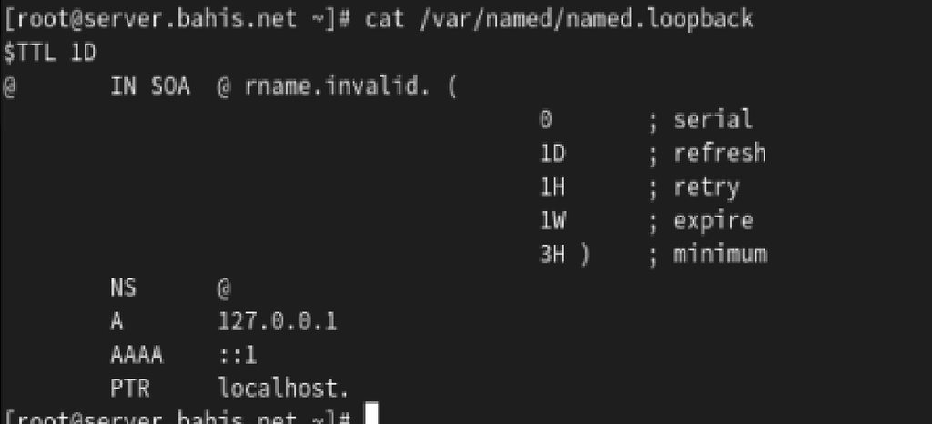

Рисунок 8: Содержимое файла named.loopback

- Выполнены `systemctl start named` и `enable named`
- Сравнены запросы `dig`
- Локальный сервер не отвечал до изменения настроек

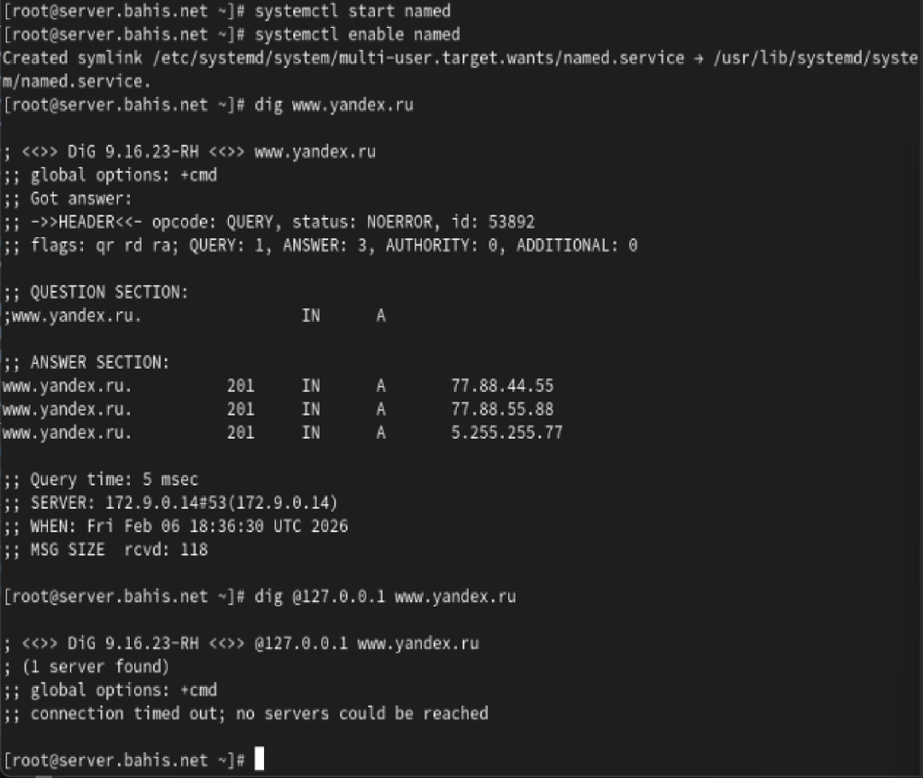

Рисунок 9: Проверка работы named и сравнение запросов dig

- Через `nmcli` установлен DNS 127.0.0.1
- Отключён auto-DNS
- После перезапуска изменён `/etc/resolv.conf`